# Experimentação Agronômica - Exemplos

José Genivaldo do Vale Moreira

2022-07-14

# Capítulo 6: Experimentos Fatoriais

## Exemplo 6.4 (Pág. 178)

Para a obtenção da Análise de Variância de um Experimento Fatorial com 2 fatores, suponha o seguinte ensaio em que foram estudados os efeitos de 4 inseticidas aplicadas em 2 doses diferenetes sobre s produção da cultura do milho, em kg/parcela:

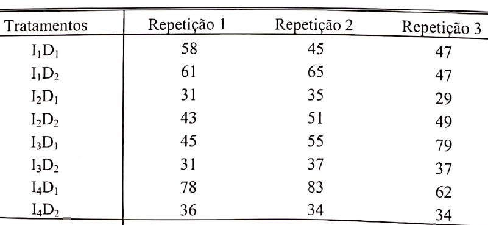

As hipóteses a serem testadas são:  
**Para o efeito dos inseticida** H<sub>0</sub>: Os inseticidas não diferem entre si quanto à produção da cultura do milho.

**Para o efeito das doses** H<sub>0</sub>: As dosagens não diferem entre si em relação à produção da cultura do milho.

**Para o efeito da interação** H<sub>0</sub>: Os inseticidas e as dosagens não agem conjuntamente sobre a produção da cultura do milho.

### Carregar os dados

Carregar os dados a partir do link.

```r
dados6_4 = read.csv("https://raw.githubusercontent.com/genivaldomoreira/Analise_experimentos_agronomicos/main/Dados/exemplo6_4.csv", header = TRUE, sep = ";", dec = ".")
head(dados6_4, 8) # exibir as 8 primeiras linhas para conferir
```

```
##    inseticida  dose producao
## 1 inseticida1 dose1       58
## 2 inseticida1 dose1       45
## 3 inseticida1 dose1       47
## 4 inseticida1 dose2       61
## 5 inseticida1 dose2       65
## 6 inseticida1 dose2       47
## 7 inseticida2 dose1       31
## 8 inseticida2 dose1       35
```

### Determinação da Anova Fatorial

```r
anova6_4 = aov(producao ~ inseticida + dose + inseticida:dose,
               data = dados6_4)
summary(anova6_4)
```

```
##                 Df Sum Sq Mean Sq F value   Pr(>F)
## inseticida       3  860.3   286.8   3.798 0.031288 *
## dose             1  620.2   620.2   8.214 0.011203 *
## inseticida:dose  3 3124.8  1041.6  13.796 0.000106 ***
## Residuals       16 1208.0    75.5
## ---
## Signif. codes:  0 '***' 0.001 '**' 0.01 '*' 0.05 '.' 0.1 ' ' 1
```

**Conclusões**:  
**Para o efeito dos inseticida** H<sub>0</sub>: Rejeita-se a hipóteses nula (p < 0,05).

**Para o efeito das doses** H<sub>0</sub>: Rejeita-se a hipóteses nula (p < 0,05).

**Para o efeito da interação** H<sub>0</sub>: Rejeita-se a hipóteses nula (p < 0,05).

### Análise dos pressupostos

#### Visualização gráfica prévia

```
## hat values (leverages) are all = 0.3333333
##  and there are no factor predictors; no plot no. 5
```

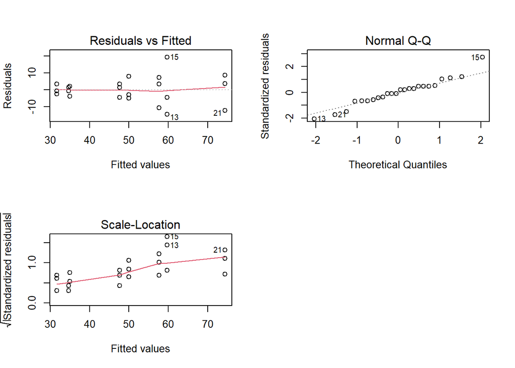

```r
par(mfrow=c(2,2)) #visualizar 4 gráficos na mesma figura (2 linhas e 2 colunas)
plot(anova6_4) # plotar o gráfico
```

```r
par(mfrow=c(1,1)) # retornar a visualização gráfica normal
```

#### Normalidade dos resíduos

```r
residuos6_4 = anova6_4$residuals # cria um objeto com os resíduos do modelo

library(nortest)
shapiro.test(residuos6_4)
```

```
##
##  Shapiro-Wilk normality test
##
## data:  residuos6_4
## W = 0.95902, p-value = 0.4191
```

```r
ad.test(residuos6_4)
```

```
##
##  Anderson-Darling normality test
##
## data:  residuos6_4
## A = 0.40668, p-value = 0.3236
```

```r
ks.test(residuos6_4, "pnorm", mean(residuos6_4), sd(residuos6_4))
```

```
##
##  One-sample Kolmogorov-Smirnov test
##
## data:  residuos6_4
## D = 0.13978, p-value = 0.7364
## alternative hypothesis: two-sided
```

Verificou-se que os resíduos apresentaram normalidade (p-valor > 0,05)

#### Homogeneidade das variâncias

```r
library(car)
leveneTest(residuos6_4 ~ dados6_4$inseticida)
```

```
## Levene's Test for Homogeneity of Variance (center = median)
##       Df F value Pr(>F)
## group  3  1.2783 0.3089
##       20
```

```r
bartlett.test(residuos6_4 ~ dados6_4$inseticida)
```

```
##
##  Bartlett test of homogeneity of variances
##
## data:  residuos6_4 by dados6_4$inseticida
## Bartlett's K-squared = 5.976, df = 3, p-value = 0.1128
```

```r
leveneTest(residuos6_4 ~ dados6_4$dose)
```

```
## Levene's Test for Homogeneity of Variance (center = median)
##       Df F value  Pr(>F)
## group  1  3.5873 0.07145 .
##       22
## ---
## Signif. codes:  0 '***' 0.001 '**' 0.01 '*' 0.05 '.' 0.1 ' ' 1
```

```r
bartlett.test(residuos6_4 ~ dados6_4$dose)
```

```
##
##  Bartlett test of homogeneity of variances
##
## data:  residuos6_4 by dados6_4$dose
## Bartlett's K-squared = 4.7482, df = 1, p-value = 0.02933
```

Análise do desdobramento da interação e estudo dos efeitos de cada um dos fatores fixando-se os níveis do outro fator.

Utilizando o pacote **ExpDes**

```r
library(ExpDes)
library(ExpDes.pt)
fat2.dic(dados6_4$inseticida,dados6_4$dose,dados6_4$producao,
            quali = c(TRUE, TRUE), mcomp = "tukey",
            fac.names = c("Inseticida", "Dose"),
            sigT = 0.05, sigF = 0.05)
```

```
## ------------------------------------------------------------------------
## Legenda:
## FATOR 1:  Inseticida
## FATOR 2:  Dose
## ------------------------------------------------------------------------
##
##
## Quadro da analise de variancia
## ------------------------------------------------------------------------
##                 GL     SQ QM      Fc     Pr>Fc
## Inseticida       3  860.3  3  3.7984 0.0312885
## Dose             1  620.2  4  8.2141 0.0112029
## Inseticida*Dose  3 3124.8  2 13.7962 0.0001057
## Residuo         16 1208.0  5
## Total           23 5813.3  1
## ------------------------------------------------------------------------
## CV = 17.79 %
##
## ------------------------------------------------------------------------
## Teste de normalidade dos residuos (Shapiro-Wilk)
## valor-p:  0.419147
## De acordo com o teste de Shapiro-Wilk a 5% de significancia, os residuos podem ser considerados normais.
## ------------------------------------------------------------------------
##
##
##
## Interacao significativa: desdobrando a interacao
## ------------------------------------------------------------------------
##
## Desdobrando  Inseticida  dentro de cada nivel de  Dose
## ------------------------------------------------------------------------
## ------------------------------------------------------------------------
## Quadro da analise de variancia
## ------------------------------------------------------------------------
##                       GL        SQ       QM      Fc  Pr.Fc
## Dose                   1  620.1667 620.1667  8.2141 0.0112
## Inseticida:Dose dose1  3 2880.9167 960.3056 12.7193  2e-04
## Inseticida:Dose dose2  3 1104.2500 368.0833  4.8753 0.0135
## Residuo               16 1208.0000  75.5000
## Total                 23 5813.3333 252.7536
```

[output cut: 69 more lines]

```
## ------------------------------------------------------------------------
## Grupos Tratamentos Medias
## a     dose1   59.66667
##  b    dose2   35
## ------------------------------------------------------------------------
##
##
##  Dose  dentro do nivel  inseticida4  de  Inseticida
## ------------------------------------------------------------------------
## Teste de Tukey
## ------------------------------------------------------------------------
## Grupos Tratamentos Medias
## a     dose1   74.33333
##  b    dose2   34.66667
## ------------------------------------------------------------------------
```

OBS: Caso deseje cosultar o comando executado, use `help("fat2.dic")`

Utilizando o pacote **easyanova**

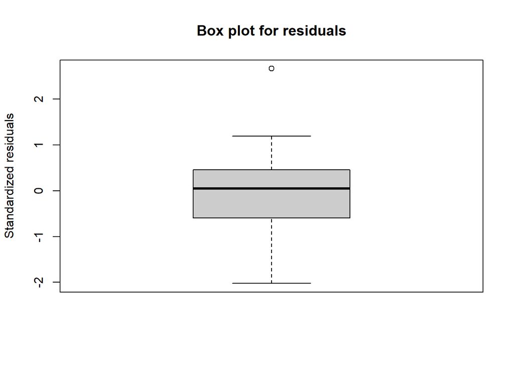

```r
library(easyanova)
ea6_4 = ea2(dados6_4, design = 1, alpha = 0.05, cov = 4, list = FALSE,
    p.adjust=1, plot=1)
```

```r
ea6_4$`Adjusted means (factor 1)`
```

```
##      factor_1 adjusted.mean standard.error tukey snk duncan  t scott_knott
## 1 inseticida4       54.5000         3.5473     a   a      a  a           a
## 2 inseticida1       53.8333         3.5473    ab   a      a  a           a
## 3 inseticida3       47.3333         3.5473    ab  ab     ab ab           b
## 4 inseticida2       39.6667         3.5473     b   b      b  b           b
```

```r
ea6_4$`Adjusted means (factor 2)`
```

```
##   factor_2 adjusted.mean standard.error tukey snk duncan t scott_knott
## 1    dose1       53.9167         2.5083     a   a      a a           a
## 2    dose2       43.7500         2.5083     b   b      b b           b
```

```r
ea6_4$`Adjusted means (factor 1 in levels of factor 2)`
```

```
## $`factor_1 in  dose1`
##           treatment adjusted.mean standard.error tukey snk duncan  t
## 4 inseticida4.dose1       74.3333         5.0166     a   a      a  a
## 3 inseticida3.dose1       59.6667         5.0166    ab  ab     ab ab
## 1 inseticida1.dose1       50.0000         5.0166    bc   b      b  b
## 2 inseticida2.dose1       31.6667         5.0166     c   c      c  c
##   scott_knott
## 4           a
## 3           a
## 1           b
## 2           c
##
## $`factor_1 in  dose2`
##           treatment adjusted.mean standard.error tukey snk duncan  t
## 5 inseticida1.dose2       57.6667         5.0166     a   a      a  a
## 6 inseticida2.dose2       47.6667         5.0166    ab  ab     ab ab
## 7 inseticida3.dose2       35.0000         5.0166     b   b      b  b
## 8 inseticida4.dose2       34.6667         5.0166     b   b      b  b
##   scott_knott
## 5           a
## 6           a
## 7           b
## 8           b
```

```r
ea6_4$`Adjusted means (factor 2 in levels of factor 1)`
```

```
## $`factor_2 in  inseticida1`
##           treatment adjusted.mean standard.error tukey snk duncan t scott_knott
## 5 inseticida1.dose2       57.6667         5.0166     a   a      a a           a
## 1 inseticida1.dose1       50.0000         5.0166     a   a      a a           a
##
## $`factor_2 in  inseticida2`
##           treatment adjusted.mean standard.error tukey snk duncan t scott_knott
## 6 inseticida2.dose2       47.6667         5.0166     a   a      a a           a
## 2 inseticida2.dose1       31.6667         5.0166     b   b      b b           b
##
## $`factor_2 in  inseticida3`
##           treatment adjusted.mean standard.error tukey snk duncan t scott_knott
## 3 inseticida3.dose1       59.6667         5.0166     a   a      a a           a
## 7 inseticida3.dose2       35.0000         5.0166     b   b      b b           b
##
## $`factor_2 in  inseticida4`
##           treatment adjusted.mean standard.error tukey snk duncan t scott_knott
## 4 inseticida4.dose1       74.3333         5.0166     a   a      a a           a
## 8 inseticida4.dose2       34.6667         5.0166     b   b      b b           b
```

```r
ea6_4$`Analysis of variance`
```

```
##                   df type III SS mean square F value    p>F
## factor_1           3    860.3333    286.7778  3.7984 0.0313
## factor_2           1    620.1667    620.1667  8.2141 0.0112
## factor_1:factor_2  3   3124.8333   1041.6111 13.7962 <0.001
## residuals         16   1208.0000     75.5000       -      -
```

```r
ea6_4$`Residual analysis`
```

```
## $`residual analysis`
##                                     values
## p.value Shapiro-Wilk test           0.4191
## p.value Bartlett test (factor_1)    0.1128
## p.value Bartlett test (factor_2)    0.0293
## p.value Bartlett test (treatments)  0.0673
## coefficient of variation (%)       17.7900
## first value most discrepant        15.0000
## second value most discrepant       13.0000
## third value most discrepant        21.0000
##
## $residuals
##           1           2           3           4           5           6
##   8.0000000  -5.0000000  -3.0000000   3.3333333   7.3333333 -10.6666667
##           7           8           9          10          11          12
##  -0.6666667   3.3333333  -2.6666667  -4.6666667   3.3333333   1.3333333
##          13          14          15          16          17          18
## -14.6666667  -4.6666667  19.3333333  -4.0000000   2.0000000   2.0000000
##          19          20          21          22          23          24
##   3.6666667   8.6666667 -12.3333333   1.3333333  -0.6666667  -0.6666667
##
## $`standardized residuals`
##          1          2          3          4          5          6          7
##  1.1038764 -0.6899227 -0.4139536  0.4599485  1.0118867 -1.4718352 -0.0919897
##          8          9         10         11         12         13         14
##  0.4599485 -0.3679588 -0.6439279  0.4599485  0.1839794 -2.0237734 -0.6439279
##         15         16         17         18         19         20         21
##  2.6677012 -0.5519382  0.2759691  0.2759691  0.5059433  1.1958661 -1.7018094
##         22         23         24
##  0.1839794 -0.0919897 -0.0919897
```

Para facilitar a interpretação dos resultados, preparamos uma tabela com a análise dos efeitos principais e dos efeitos da interação entre os fatores.  
Tabela 6.1: Analise dos efeitos dos tratamentos e da interação

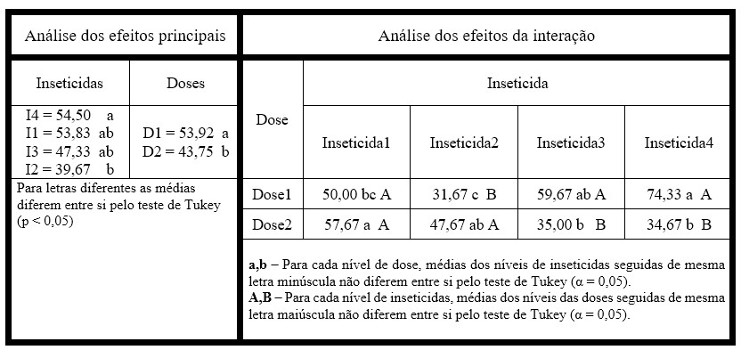

## Exemplo 6.7 (Pág. 186)

Considere um trabalho em que foram utilizados 3 espaçamentos entre linhas (25 cm, 50 cm e 75 cm) e 3 densidades de plantas por metro linear (15, 30 e 45 plantas por metro linear). O delineamento foi instalado em blocos casualizados com 3 repetições, e os dados obtidos para a produção de massa verda (t/ha), 139 dias após a semeadura, foram os seguintes:

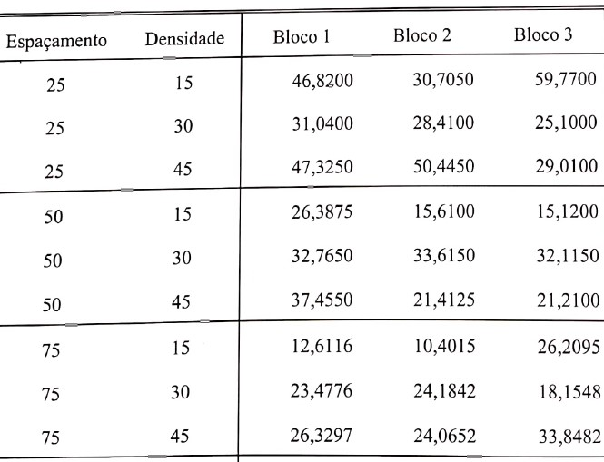

As hipóteses a serem testadas são:  
**Para o efeito dos espaçamentos** H<sub>0</sub>: Os espaçamentos não apresentam diferença em relação à produção de massa verde de *Crotalaria juncea*, ao nível de sigificância 5%.

**Para o efeito das densidades** H<sub>0</sub>: As densidades não apresentam diferença em relação à produção de massa verde de *Crotalaria juncea*, ao nível de sigificância 5%.

**Para o efeito da interação** H<sub>0</sub>: Os espaçamentos e as densidades não agem conjuntamente sobre a produção de massa verde de *Crotalaria juncea*, ao nível de sigificância 5%.

### Carregar os dados

Carregar os dados a partir do link.

```r
dados6_7 = read.csv("https://raw.githubusercontent.com/genivaldomoreira/Analise_experimentos_agronomicos/main/Dados/exemplo6_7.csv", header = TRUE, sep = ";", dec = ".")
head(dados6_7, 8) # exibir as 8 primeiras linhas para conferir
```

```
##   espacamento densidade  bloco massa_verde
## 1          25        15 bloco1      46.820
## 2          25        15 bloco2      30.705
## 3          25        15 bloco3      59.770
## 4          25        30 bloco1      31.040
## 5          25        30 bloco2      28.410
## 6          25        30 bloco3      25.100
## 7          25        45 bloco1      47.325
## 8          25        45 bloco2      50.445
```

Considerando que os níveis dos fatores são quantitativos, vamos torná-los em fatores, para fins de realização da Anova.

```r
espacamento=as.factor(dados6_7$espacamento)
densidade = as.factor(dados6_7$densidade)
bloco = as.factor(dados6_7$bloco)
massa_verde = dados6_7$massa_verde

dados6_7 = data.frame(espacamento, densidade, bloco, massa_verde)
str(dados6_7)
```

```
## 'data.frame':    27 obs. of  4 variables:
##  $ espacamento: Factor w/ 3 levels "25","50","75": 1 1 1 1 1 1 1 1 1 2 ...
##  $ densidade  : Factor w/ 3 levels "15","30","45": 1 1 1 2 2 2 3 3 3 1 ...
##  $ bloco      : Factor w/ 3 levels "bloco1","bloco2",..: 1 2 3 1 2 3 1 2 3 1 ...
##  $ massa_verde: num  46.8 30.7 59.8 31 28.4 ...
```

### Determinação da Anova Fatorial

```r
anova6_7 = aov(massa_verde ~ espacamento + densidade + bloco + espacamento:densidade, data = dados6_7)
summary(anova6_7)
```

```
##                       Df Sum Sq Mean Sq F value  Pr(>F)
## espacamento            2 1347.5   673.8  10.053 0.00149 **
## densidade              2  150.5    75.3   1.123 0.34963
## bloco                  2  114.4    57.2   0.853 0.44446
## espacamento:densidade  4  860.1   215.0   3.208 0.04101 *
## Residuals             16 1072.4    67.0
## ---
## Signif. codes:  0 '***' 0.001 '**' 0.01 '*' 0.05 '.' 0.1 ' ' 1
```

**Conclusões**:  
**Para o efeito dos espaçamentos** H<sub>0</sub>: Rejeita-se a hipóteses nula (p < 0,05).

**Para o efeito das densidades** H<sub>0</sub>: Não se rejeita a hipóteses nula (p > 0,05).

**Para o efeito da interação** H<sub>0</sub>: Rejeita-se a hipóteses nula (p < 0,05).

### Análise dos pressupostos

#### Visualização gráfica prévia

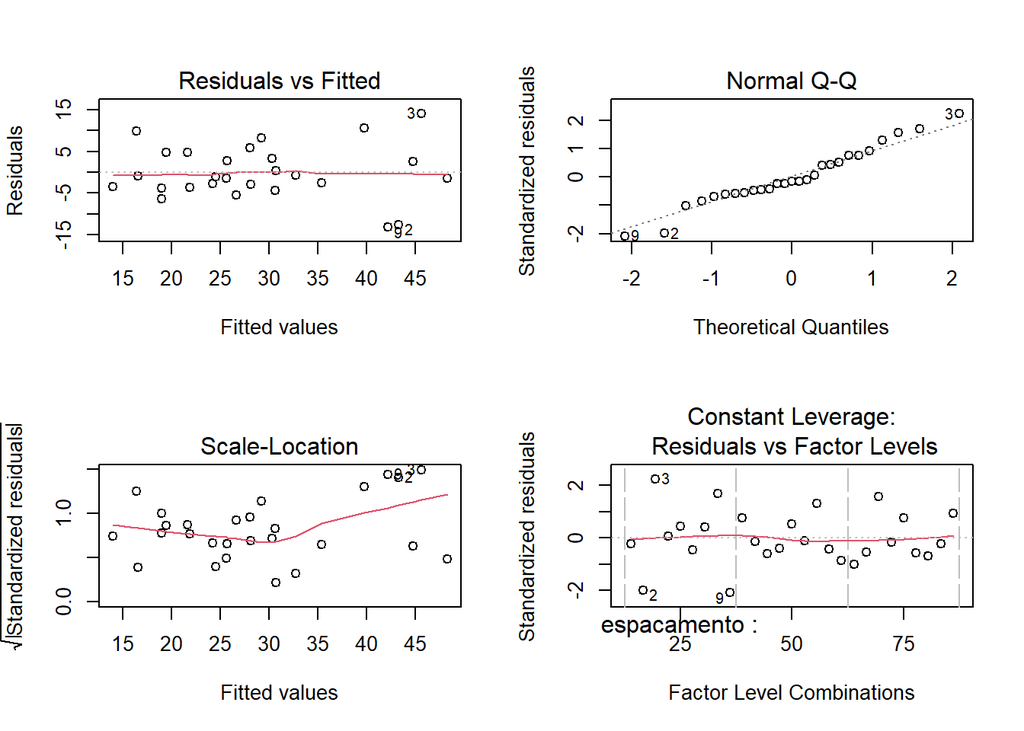

```r
par(mfrow=c(2,2)) #visualizar 4 gráficos na mesma figura (2 linhas e 2 colunas)
plot(anova6_7) # plotar o gráfico
```

```r
par(mfrow=c(1,1)) # retornar a visualização gráfica normal
```

#### Normalidade dos resíduos

```r
residuos6_7 = anova6_7$residuals # cria um objeto com os resíduos do modelo

library(nortest)
shapiro.test(residuos6_7)
```

```
##
##  Shapiro-Wilk normality test
##
## data:  residuos6_7
## W = 0.96767, p-value = 0.5415
```

```r
ad.test(residuos6_7)
```

```
##
##  Anderson-Darling normality test
##
## data:  residuos6_7
## A = 0.4168, p-value = 0.3086
```

```r
ks.test(residuos6_7, "pnorm", mean(residuos6_7), sd(residuos6_7))
```

```
##
##  One-sample Kolmogorov-Smirnov test
##
## data:  residuos6_7
## D = 0.13248, p-value = 0.6818
## alternative hypothesis: two-sided
```

#### Homogeneidade das variâncias

```r
library(car)
leveneTest(residuos6_7 ~ dados6_7$espacamento)
```

```
## Levene's Test for Homogeneity of Variance (center = median)
##       Df F value Pr(>F)
## group  2  1.4766 0.2484
##       24
```

```r
bartlett.test(residuos6_7 ~ dados6_7$densidade)
```

```
##
##  Bartlett test of homogeneity of variances
##
## data:  residuos6_7 by dados6_7$densidade
## Bartlett's K-squared = 7.1529, df = 2, p-value = 0.02798
```

```r
leveneTest(residuos6_7 ~ dados6_7$espacamento)
```

```
## Levene's Test for Homogeneity of Variance (center = median)
##       Df F value Pr(>F)
## group  2  1.4766 0.2484
##       24
```

```r
bartlett.test(residuos6_7 ~ dados6_7$densidade)
```

```
##
##  Bartlett test of homogeneity of variances
##
## data:  residuos6_7 by dados6_7$densidade
## Bartlett's K-squared = 7.1529, df = 2, p-value = 0.02798
```

Análise do desdobramento da interação e estudo dos efeitos de cada um dos fatores fixando-se os níveis do outro fator.

Utilizando o pacote **ExpDes**

```r
library(ExpDes)
library(ExpDes.pt)
fat2.dbc(dados6_7$espacamento, dados6_7$densidade,
         dados6_7$bloco, dados6_7$massa_verde, quali=c(TRUE,TRUE),
         mcomp="lsd", fac.names=c("Espaçamento","Densidade"),
         sigT = 0.05, sigF = 0.05)
```

```
## ------------------------------------------------------------------------
## Legenda:
## FATOR 1:  Espaçamento
## FATOR 2:  Densidade
## ------------------------------------------------------------------------
##
##
## Quadro da analise de variancia
## ------------------------------------------------------------------------
##                       GL     SQ QM      Fc   Pr>Fc
## Bloco                  2  114.4  3  0.8534 0.44446
## Espaçamento            2 1347.5  5 10.0528 0.00149
## Densidade              2  150.5  6  1.1230 0.34963
## Espaçamento*Densidade  4  860.1  2  3.2083 0.04101
## Residuo               16 1072.4  4
## Total                 26 3544.9  1
## ------------------------------------------------------------------------
## CV = 28.21 %
##
## ------------------------------------------------------------------------
## Teste de normalidade dos residuos (Shapiro-Wilk)
## valor-p:  0.5415215
## De acordo com o teste de Shapiro-Wilk a 5% de significancia, os residuos podem ser considerados normais.
## ------------------------------------------------------------------------
##
##
##
## Interacao significativa: desdobrando a interacao
## ------------------------------------------------------------------------
##
## Desdobrando  Espaçamento  dentro de cada nivel de  Densidade
## ------------------------------------------------------------------------
## ------------------------------------------------------------------------
## Quadro da analise de variancia
## ------------------------------------------------------------------------
##                          GL        SQ        QM     Fc  Pr.Fc
## Bloco                     2  114.3953  57.19764 0.8534 0.4445
## Densidade                 2  150.5342  75.26709  1.123 0.3496
## Espaçamento:Densidade 15  2 1583.0565 791.52826  11.81  7e-04
## Espaçamento:Densidade 30  2  179.2535  89.62673 1.3373 0.2904
```

[output cut: 74 more lines]

```
## 1      1 19.03917
## 2      2 32.83167
## 3      3 26.69250
## ------------------------------------------------------------------------
##
##
##  Densidade  dentro do nivel  75  de  Espaçamento
##
## De acordo com o teste F, as medias desse fator sao estatisticamente iguais.
## ------------------------------------------------------------------------
##   Niveis   Medias
## 1      1 16.40753
## 2      2 21.93887
## 3      3 28.08103
## ------------------------------------------------------------------------
```

OBS: Caso deseje cosultar o comando executado, use `help("fat2.dbc")`

Utilizando o pacote **easyanova**

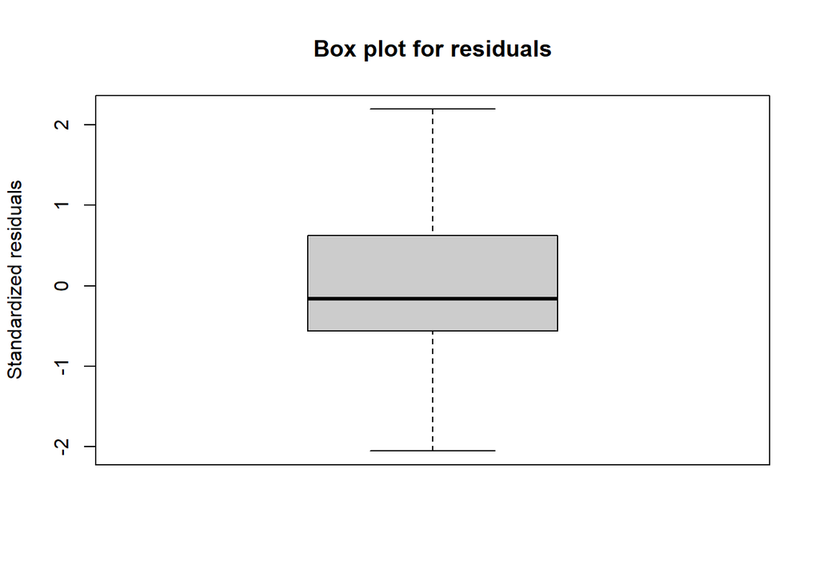

```r
library(easyanova)
ea6_7 = ea2(dados6_7, design = 2, alpha = 0.05, cov = 1,
    list = FALSE, p.adjust=1, plot=1)
```

```r
ea6_7$`Analysis of variance`
```

```
##                   df type III SS mean square F value    p>F
## factor_1           2   1347.5214    673.7607 10.0528 0.0015
## factor_2           2    150.5342     75.2671   1.123 0.3496
## blocks             2    114.3953     57.1976  0.8534 0.4445
## factor_1:factor_2  4    860.1068    215.0267  3.2083  0.041
## residuals         16   1072.3503     67.0219       -      -
```

```r
ea6_7$`Adjusted means (factor 1)`
```

```
##   factor_1 adjusted.mean standard.error tukey snk duncan t scott_knott
## 1       25       38.7361         2.7289     a   a      a a           a
## 2       50       26.1878         2.7289     b   b      b b           b
## 3       75       22.1425         2.7289     b   b      b b           b
```

```r
ea6_7$`Adjusted means (factor 2)`
```

```
##   factor_2 adjusted.mean standard.error tukey snk duncan t scott_knott
## 1       45      32.34451         2.7289     a   a      a a           a
## 2       30      27.65129         2.7289     a   a      a a           a
## 3       15      27.07057         2.7289     a   a      a a           a
```

```r
ea6_7$`Adjusted means (factor 1 in levels of factor 2)`
```

```
## $`factor_1 in  15`
##   treatment adjusted.mean standard.error tukey snk duncan t scott_knott
## 1     25.15       45.7650         4.7266     a   a      a a           a
## 2     50.15       19.0392         4.7266     b   b      b b           b
## 3     75.15       16.4075         4.7266     b   b      b b           b
##
## $`factor_1 in  30`
##   treatment adjusted.mean standard.error tukey snk duncan t scott_knott
## 5     50.30       32.8317         4.7266     a   a      a a           a
## 4     25.30       28.1833         4.7266     a   a      a a           a
## 6     75.30       21.9389         4.7266     a   a      a a           a
##
## $`factor_1 in  45`
##   treatment adjusted.mean standard.error tukey snk duncan t scott_knott
## 7     25.45       42.2600         4.7266     a   a      a a           a
## 9     75.45       28.0810         4.7266     a   b      b b           b
## 8     50.45       26.6925         4.7266     a  ab      b b           b
```

```r
ea6_7$`Adjusted means (factor 2 in levels of factor 1)`
```

```
## $`factor_2 in  25`
##   treatment adjusted.mean standard.error tukey snk duncan  t scott_knott
## 1     25.15       45.7650         4.7266     a   a      a  a           a
## 7     25.45       42.2600         4.7266    ab  ab     ab ab           a
## 4     25.30       28.1833         4.7266     b   b      b  b           b
##
## $`factor_2 in  50`
##   treatment adjusted.mean standard.error tukey snk duncan t scott_knott
## 5     50.30       32.8317         4.7266     a   a      a a           a
## 8     50.45       26.6925         4.7266     a   a      a a           a
## 2     50.15       19.0392         4.7266     a   a      a a           a
##
## $`factor_2 in  75`
##   treatment adjusted.mean standard.error tukey snk duncan t scott_knott
## 9     75.45       28.0810         4.7266     a   a      a a           a
## 6     75.30       21.9389         4.7266     a   a      a a           a
## 3     75.15       16.4075         4.7266     a   a      a a           a
```

OBS: Recomendamos uma comparação dos resultados aqui obtidos com os resultados apresentados no livro (páginas 192 e 195). Em seguida, aconselhamos a construção de uma tabela que apresente os resultados de forma resumida dos efeitos simples bem como da interação entre os fatores, conforme Tabela 6.1 apresentada no Exemplo anterior.

# Capítulo 7: Experimentos Fatoriais com 3 fatores

## Exemplo 7.2 (Pág. 214)

Analisar os seguintes dados adapatados do trabalho “Efeitos da Adubação N, P e K no desenvolvimento inicial de progênies de *Eucaliptus grandis Hill Ex Maiden* em condições de casa de vegetação”, realizado por Pires (1992). As alturas das plantas em cm, 150 dias após a semeadura foram:

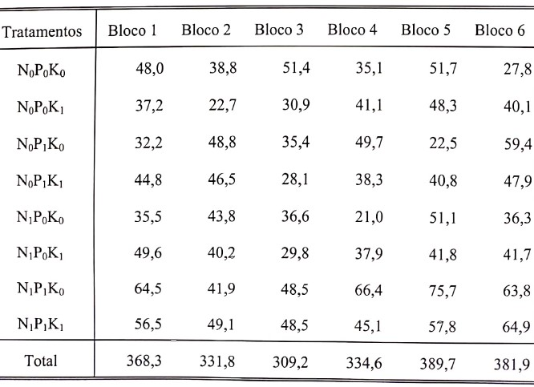

As hipóteses a serem testadas são:  
**Para efeito de N** - H<sub>0</sub>: Os níveis de N possuem efeitos semelhantes sobre a altura das mudas de *Eucaliptus grandis*.  
**Para efeito de P** - H<sub>0</sub>: Os níveis de P possuem efeitos semelhantes sobre a altura das mudas de *Eucaliptus grandis*.  
**Para efeito de K** - H<sub>0</sub>: Os níveis de K possuem efeitos semelhantes sobre a altura das mudas de *Eucaliptus grandis*.  
**Para efeito da interação NxP** - H<sub>0</sub>: Os fatores N e P agem independentemente sobre a altura das mudas de *Eucaliptus grandis*.  
**Para efeito da interação NxK** - H<sub>0</sub>: Os fatores N e K agem independentemente sobre a altura das mudas de *Eucaliptus grandis*.  
**Para efeito da interação PxK** - H<sub>0</sub>: Os fatores P e K agem independentemente sobre a altura das mudas de *Eucaliptus grandis*.  
**Para efeito da interação NxPxK** - H<sub>0</sub>: Os fatores N, P e K agem independentemente sobre a altura das mudas de *Eucaliptus grandis*.

### Carregar os dados

Carregar os dados a partir do link.

```r
dados7_2 = read.csv("https://raw.githubusercontent.com/genivaldomoreira/Analise_experimentos_agronomicos/main/Dados/exemplo7_2.csv", header = TRUE, sep = ";", dec = ".")
head(dados7_2, 10) # exibir as 10 primeiras linhas para conferir
```

```
##    nitrogenio fosfoso potassio  bloco altura
## 1          N0      P0       K0 bloco1   48.0
## 2          N0      P0       K0 bloco2   38.8
## 3          N0      P0       K0 bloco3   51.4
## 4          N0      P0       K0 bloco4   35.1
## 5          N0      P0       K0 bloco5   51.7
## 6          N0      P0       K0 bloco6   27.8
## 7          N0      P0       K1 bloco1   37.2
## 8          N0      P0       K1 bloco2   22.7
## 9          N0      P0       K1 bloco3   30.9
## 10         N0      P0       K1 bloco4   41.1
```

Análise por meio do pacote **ExpDes**

```r
library(ExpDes)
library(ExpDes.pt)
fat3.dbc(dados7_2$nitrogenio, dados7_2$fosfoso,
         dados7_2$potassio, dados7_2$bloco,
         dados7_2$altura, quali = c(TRUE, TRUE, TRUE),
         mcomp = "tukey",
         fac.names = c("Nitrogênio", "Fósforo", "Potássio"),
         sigT = 0.05, sigF = 0.05)
```

[output not shown]

[output cut: 55 more lines]

```
## ------------------------------------------------------------------------
## Grupos Tratamentos Medias
## a     P1      56.89167
##  b    P0      38.775
## ------------------------------------------------------------------------
##
## Analisando os efeitos simples do fator  Potássio
## ------------------------------------------------------------------------
## Potássio
## De acordo com o teste F, as medias desse fator sao estatisticamente iguais.
## ------------------------------------------------------------------------
##   Niveis   Medias
## 1     K0 45.24583
## 2     K1 42.90000
## ------------------------------------------------------------------------
```

OBS: Caso deseje cosultar o comando executado, use `help("fat3.dbc")`

Análise por meio do pacote **easyanova**

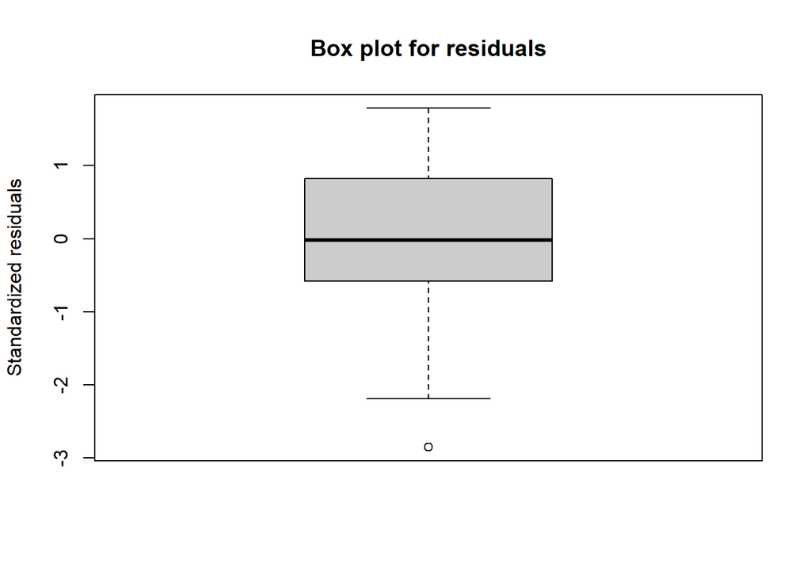

```r
library(easyanova)
ea7_2 = ea2(dados7_2, design = 8, alpha = 0.05, cov = 4,
    list = FALSE, p.adjust=1, plot=1)
```

```r
ea7_2
```

```
## $`Analysis of variance`
##                            df type III SS mean square F value    p>F
## factor_1                    1    678.7552    678.7552  7.4511 0.0099
## factor_2                    1   1187.0352   1187.0352 13.0308 <0.001
## factor_3                    1     66.0352     66.0352  0.7249 0.4003
## blocks                      5    640.1985    128.0397  1.4056 0.2463
## factor_1:factor_2           1    801.1502    801.1502  8.7947 0.0054
## factor_1:factor_3           1      2.9502      2.9502  0.0324 0.8582
## factor_2:factor_3           1     12.7102     12.7102  0.1395  0.711
## factor_1:factor_2:factor_3  1    155.8802    155.8802  1.7112 0.1994
## residuals                  35   3188.2998     91.0943       -      -
##
## $`Adjusted means (factor 1)`
##   factor_1 adjusted.mean standard.error tukey snk duncan t
## 1       N1       47.8333         1.9482     a   a      a a
## 2       N0       40.3125         1.9482     b   b      b b
##
## $`Multiple comparison test (factor 1)`
##      pair contrast p(tukey) p(snk) p(duncan)   p(t)
## 1 N1 - N0   7.5208   0.0099 0.0099    0.0099 0.0099
##
## $`Adjusted means (factor 2)`
##   factor_2 adjusted.mean standard.error tukey snk duncan t
## 1       P1       49.0458         1.9482     a   a      a a
## 2       P0       39.1000         1.9482     b   b      b b
##
## $`Multiple comparison test (factor 2)`
##      pair contrast p(tukey) p(snk) p(duncan)  p(t)
## 1 P1 - P0   9.9458    9e-04  9e-04     9e-04 9e-04
##
## $`Adjusted means (factor 3)`
##   factor_3 adjusted.mean standard.error tukey snk duncan t
## 1       K0       45.2458         1.9482     a   a      a a
## 2       K1       42.9000         1.9482     a   a      a a
##
## $`Multiple comparison test (factor 3)`
##      pair contrast p(tukey) p(snk) p(duncan)   p(t)
## 1 K0 - K1   2.3458   0.4003 0.4003    0.4003 0.4003
##
## $`Adjusted means (factor 1 in levels of factor 2)`
```

[output cut: 291 more lines]

```
##  0.8430696007 -0.0341477336 -1.3474442733  1.2219829706 -0.0619718128
##            16            17            18            19            20
##  1.2887607608 -2.8499445519  1.7486169066  0.2147513024  0.9751075040
##            21            22            23            24            25
## -0.9159180991 -0.0629835975 -0.5956882417  0.3847311319 -0.4671915849
##            26            27            28            29            30
##  1.0944980985  0.5633111314 -1.7162397963  1.1020864838 -0.5764643324
##            31            32            33            34            35
##  0.9068120368  0.3194710188 -0.6002412729 -0.0022765156 -0.3650013303
##            36            37            38            39            40
## -0.2587639369  0.2916469396 -1.8983610421 -0.7540325472  1.0337910165
##            41            42            43            44            45
##  1.3267026870  0.0002529462  0.1075021243 -0.2370105658  0.0331359489
##            46            47            48
## -0.7651621789 -0.0594423511  0.9209770226
```

## Exemplo 8.2 (Pág. 228) - Experimentos fatoriais com tratamentos adicionais

Suponha um ensaio em que foram estudados os efeitos de dois métodos de aplicação (Pulverização e UBV) e duas doses (0,5 e 0,7 l/ha) do inseticida Lorsbson sobre o controle do tripes na cultura do amendoim. os resultados obtidos para numero de tripes (tomando 10 ponteiros por parcela) transformados em $sqrt(x)$, foram:

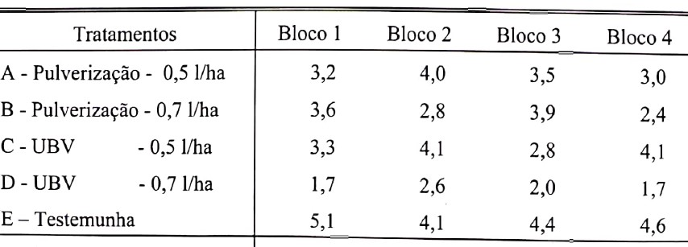

As hipóteses a serem testadas são:  
**Para testemunha versus tratados** - H<sub>0</sub>: O inseticida Lorsban possui efeito semelhante ao tratamento testemunha no controle do tripes na cultura do amendoim.  
**Para efeito dos métodos** - H<sub>0</sub>: Os métodos de aplicaçao do inseticida possuem efeitos semelhtantes entre si em relação ao controle do tripes na cultura do amendoim.  
**Para efeito da doses** - H<sub>0</sub>: As doses de aplicaçao do inseticida possuem efeitos semelhtantes entre si em relação ao controle do tripes na cultura do amendoim.  
**Para efeito da interação entre métodos e doses** - H<sub>0</sub>: Os métodos de aplicação e as doses agem independentemente sobre o controle do tripes na cultura do ameindoim.

OBS: Da mesma forma do exemplo anterior, apresentaremos apenas o script para a realização dos testes e recomendamos ao leitor uma análise crítica dos resultados, comparando os resultados do livro adotado como referência (páginas 228 a 232).

### Carregar os dados

Carregar os dados a partir do link.

```r
dados8_2 = read.csv("https://raw.githubusercontent.com/genivaldomoreira/Analise_experimentos_agronomicos/main/Dados/exemplo8_2.csv", header = TRUE, sep = ";", dec = ".")
head(dados8_2, 10) # exibir as 10 primeiras linhas para conferir
```

```
##          metodo dose bloco tripes
## 1  pulverizador  0.5     1    3.2
## 2  pulverizador  0.5     2    4.0
## 3  pulverizador  0.5     3    3.5
## 4  pulverizador  0.5     4    3.0
## 5  pulverizador  0.7     1    3.6
## 6  pulverizador  0.7     2    2.8
## 7  pulverizador  0.7     3    3.9
## 8  pulverizador  0.7     4    2.4
## 9           UBV  0.5     1    3.3
## 10          UBV  0.5     2    4.1
```

Análise por meio do pacote **ExpDes**

```r
library(ExpDes)
library(ExpDes.pt)
metodo = dados8_2$metodo
metodo
```

```
##  [1] "pulverizador" "pulverizador" "pulverizador" "pulverizador" "pulverizador"
##  [6] "pulverizador" "pulverizador" "pulverizador" "UBV"          "UBV"
## [11] "UBV"          "UBV"          "UBV"          "UBV"          "UBV"
## [16] "UBV"
```

```r
dose = dados8_2$dose
dose
```

```
##  [1] 0.5 0.5 0.5 0.5 0.7 0.7 0.7 0.7 0.5 0.5 0.5 0.5 0.7 0.7 0.7 0.7
```

```r
bloco = dados8_2$bloco
bloco
```

```
##  [1] 1 2 3 4 1 2 3 4 1 2 3 4 1 2 3 4
```

```r
tripes = dados8_2$tripes
tripes
```

```
##  [1] 3.2 4.0 3.5 3.0 3.6 2.8 3.9 2.4 3.3 4.1 2.8 4.1 1.7 2.6 2.0 1.7
```

```r
testemunha8_2 = c(5.1,4.1,4.4,4.6)
testemunha8_2
```

```
## [1] 5.1 4.1 4.4 4.6
```

```r
fat2.ad.dbc(metodo, dose, bloco, tripes, testemunha8_2,
            quali=c(TRUE, FALSE), mcomp = "tukey",
            fac.names = c("metodo", "dose"),
            sigT = 0.05, sigF = 0.05)
```

```
## ------------------------------------------------------------------------
## Legenda:
## FATOR 1:  metodo
## FATOR 2:  dose
## ------------------------------------------------------------------------
##
## ------------------------------------------------------------------------
## Quadro da analise de variancia
## ------------------------------------------------------------------------
##                GL       SQ      QM      Fc  Pr>Fc
## Bloco           3  0.33350 0.11117  0.3353 0.8002
## metodo          1  1.05063 1.05063  3.1685 0.1004
## dose            1  3.33062 3.33062 10.0446 0.0081
## metodo*dose     1  1.75562 1.75562  5.2947 0.0401
## Ad vs Fatorial  1  7.26013 7.26013 21.8953  5e-04
## Residuo        12  3.97900 0.33158
## Total          19 17.70950
## ------------------------------------------------------------------------
## CV = 17.21 %
##
## ------------------------------------------------------------------------
## Teste de normalidade dos residuos (Shapiro-Wilk)
## valor-p:  0.4588498
## De acordo com o teste de Shapiro-Wilk a 5% de significancia, os residuos podem ser considerados normais.
## ------------------------------------------------------------------------
##
## Contraste do tratamento adicional com o fatorial
## ------------------------------------------------------------------------
##            Medias
## Adicional 4.55000 a
## Fatorial  3.04375 b
## ------------------------------------------------------------------------
##
##
##
## Interacao significativa: desdobrando a interacao
## ------------------------------------------------------------------------
##
## Desdobrando  metodo  dentro de cada nivel de  dose
## ------------------------------------------------------------------------
```

[output cut: 75 more lines]

```
##
## R2 do modelo linear
## -
## 1
## -
##
## Analise de variancia do modelo linear
## ===================================================
##                      GL   SQ     QM    Fc   valor.p
## ---------------------------------------------------
## Efeito linear        1  4.9612 4.9612 14.96 0.00224
## Desvios de Regressao 0    0      0      0      1
## Residuos             12 3.9790 0.3316
## ---------------------------------------------------
## ------------------------------------------------------------------------
```

OBS: Caso deseje cosultar o comando executado, use `help("fat2.ad.dbc")`